# Assignment 1 - Exploratory Data Analysis

Author

Ran Zhu

## Introduction

This analysis examines whether daily PM2.5 concentrations in California decreased between 2002 and 2022.

## 1. Initial Data Examination

```r
library(tidyverse)
library(maps)
```

### 1.1 Load data

#### I downloaded the 2002 and 2022 California PM2.5 datasets from the EPA website and read each file into R as a separate data frame.

```r
pm2002 <- read_csv(
  "~/Desktop/daily_pm25_ca_2002.csv",
  show_col_types = FALSE
)

pm2022 <- read_csv(
  "~/Desktop/daily_pm25_ca_2022.csv",
  show_col_types = FALSE
)
```

### 1.2 Check the dimensions, headers, footers, variable names and variable types

```r
dim(pm2002)
```

```
[1] 15976    22
```

```r
dim(pm2022)
```

```
[1] 59918    22
```

```r
head(pm2002)
```

```
# A tibble: 6 × 22
  Date     Source `Site ID`   POC Daily Mean PM2.5 Con…¹ Units `Daily AQI Value`
  <chr>    <chr>  <chr>     <dbl>                  <dbl> <chr>             <dbl>
1 01/05/2… AQS    060010007     1                   25.1 ug/m…                81
2 01/06/2… AQS    060010007     1                   31.6 ug/m…                93
3 01/08/2… AQS    060010007     1                   21.4 ug/m…                74
4 01/11/2… AQS    060010007     1                   25.9 ug/m…                82
5 01/14/2… AQS    060010007     1                   34.5 ug/m…                98
6 01/17/2… AQS    060010007     1                   41   ug/m…               115
# ℹ abbreviated name: ¹`Daily Mean PM2.5 Concentration`
# ℹ 15 more variables: `Local Site Name` <chr>, `Daily Obs Count` <dbl>,
#   `Percent Complete` <dbl>, `AQS Parameter Code` <dbl>,
#   `AQS Parameter Description` <chr>, `Method Code` <dbl>,
#   `Method Description` <chr>, `CBSA Code` <dbl>, `CBSA Name` <chr>,
#   `State FIPS Code` <chr>, State <chr>, `County FIPS Code` <chr>,
#   County <chr>, `Site Latitude` <dbl>, `Site Longitude` <dbl>
```

```r
tail(pm2002)
```

```
# A tibble: 6 × 22
  Date     Source `Site ID`   POC Daily Mean PM2.5 Con…¹ Units `Daily AQI Value`
  <chr>    <chr>  <chr>     <dbl>                  <dbl> <chr>             <dbl>
1 12/10/2… AQS    061131003     1                     15 ug/m…                62
2 12/13/2… AQS    061131003     1                     15 ug/m…                62
3 12/22/2… AQS    061131003     1                      1 ug/m…                 6
4 12/25/2… AQS    061131003     1                     23 ug/m…                77
5 12/28/2… AQS    061131003     1                      5 ug/m…                28
6 12/31/2… AQS    061131003     1                      6 ug/m…                33
# ℹ abbreviated name: ¹`Daily Mean PM2.5 Concentration`
# ℹ 15 more variables: `Local Site Name` <chr>, `Daily Obs Count` <dbl>,
#   `Percent Complete` <dbl>, `AQS Parameter Code` <dbl>,
#   `AQS Parameter Description` <chr>, `Method Code` <dbl>,
#   `Method Description` <chr>, `CBSA Code` <dbl>, `CBSA Name` <chr>,
#   `State FIPS Code` <chr>, State <chr>, `County FIPS Code` <chr>,
#   County <chr>, `Site Latitude` <dbl>, `Site Longitude` <dbl>
```

```r
head(pm2022)
```

```
# A tibble: 6 × 22
  Date     Source `Site ID`   POC Daily Mean PM2.5 Con…¹ Units `Daily AQI Value`
  <chr>    <chr>  <chr>     <dbl>                  <dbl> <chr>             <dbl>
1 01/01/2… AQS    060010007     3                   12.7 ug/m…                58
2 01/02/2… AQS    060010007     3                   13.9 ug/m…                60
3 01/03/2… AQS    060010007     3                    7.1 ug/m…                39
4 01/04/2… AQS    060010007     3                    3.7 ug/m…                21
5 01/05/2… AQS    060010007     3                    4.2 ug/m…                23
6 01/06/2… AQS    060010007     3                    3.8 ug/m…                21
# ℹ abbreviated name: ¹`Daily Mean PM2.5 Concentration`
# ℹ 15 more variables: `Local Site Name` <chr>, `Daily Obs Count` <dbl>,
#   `Percent Complete` <dbl>, `AQS Parameter Code` <dbl>,
#   `AQS Parameter Description` <chr>, `Method Code` <dbl>,
#   `Method Description` <chr>, `CBSA Code` <dbl>, `CBSA Name` <chr>,
#   `State FIPS Code` <chr>, State <chr>, `County FIPS Code` <chr>,
#   County <chr>, `Site Latitude` <dbl>, `Site Longitude` <dbl>
```

```r
tail(pm2022)
```

```
# A tibble: 6 × 22
  Date     Source `Site ID`   POC Daily Mean PM2.5 Con…¹ Units `Daily AQI Value`
  <chr>    <chr>  <chr>     <dbl>                  <dbl> <chr>             <dbl>
1 12/01/2… AQS    061131003     1                    3.4 ug/m…                19
2 12/07/2… AQS    061131003     1                    3.8 ug/m…                21
3 12/13/2… AQS    061131003     1                    6   ug/m…                33
4 12/19/2… AQS    061131003     1                   34.8 ug/m…                99
5 12/25/2… AQS    061131003     1                   23.2 ug/m…                77
6 12/31/2… AQS    061131003     1                    1   ug/m…                 6
# ℹ abbreviated name: ¹`Daily Mean PM2.5 Concentration`
# ℹ 15 more variables: `Local Site Name` <chr>, `Daily Obs Count` <dbl>,
#   `Percent Complete` <dbl>, `AQS Parameter Code` <dbl>,
#   `AQS Parameter Description` <chr>, `Method Code` <dbl>,
#   `Method Description` <chr>, `CBSA Code` <dbl>, `CBSA Name` <chr>,
#   `State FIPS Code` <chr>, State <chr>, `County FIPS Code` <chr>,
#   County <chr>, `Site Latitude` <dbl>, `Site Longitude` <dbl>
```

```r
names(pm2002)
```

```
 [1] "Date"                           "Source"
 [3] "Site ID"                        "POC"
 [5] "Daily Mean PM2.5 Concentration" "Units"
 [7] "Daily AQI Value"                "Local Site Name"
 [9] "Daily Obs Count"                "Percent Complete"
[11] "AQS Parameter Code"             "AQS Parameter Description"
[13] "Method Code"                    "Method Description"
[15] "CBSA Code"                      "CBSA Name"
[17] "State FIPS Code"                "State"
[19] "County FIPS Code"               "County"
[21] "Site Latitude"                  "Site Longitude"
```

```r
names(pm2022)
```

```
 [1] "Date"                           "Source"
 [3] "Site ID"                        "POC"
 [5] "Daily Mean PM2.5 Concentration" "Units"
 [7] "Daily AQI Value"                "Local Site Name"
 [9] "Daily Obs Count"                "Percent Complete"
[11] "AQS Parameter Code"             "AQS Parameter Description"
[13] "Method Code"                    "Method Description"
[15] "CBSA Code"                      "CBSA Name"
[17] "State FIPS Code"                "State"
[19] "County FIPS Code"               "County"
[21] "Site Latitude"                  "Site Longitude"
```

```r
str(pm2002)
```

```
spc_tbl_ [15,976 × 22] (S3: spec_tbl_df/tbl_df/tbl/data.frame)
 $ Date                          : chr [1:15976] "01/05/2002" "01/06/2002" "01/08/2002" "01/11/2002" ...
 $ Source                        : chr [1:15976] "AQS" "AQS" "AQS" "AQS" ...
 $ Site ID                       : chr [1:15976] "060010007" "060010007" "060010007" "060010007" ...
 $ POC                           : num [1:15976] 1 1 1 1 1 1 1 1 1 1 ...
 $ Daily Mean PM2.5 Concentration: num [1:15976] 25.1 31.6 21.4 25.9 34.5 41 29.3 15 18.8 37.9 ...
 $ Units                         : chr [1:15976] "ug/m3 LC" "ug/m3 LC" "ug/m3 LC" "ug/m3 LC" ...
 $ Daily AQI Value               : num [1:15976] 81 93 74 82 98 115 89 62 69 107 ...
 $ Local Site Name               : chr [1:15976] "Livermore" "Livermore" "Livermore" "Livermore" ...
 $ Daily Obs Count               : num [1:15976] 1 1 1 1 1 1 1 1 1 1 ...
 $ Percent Complete              : num [1:15976] 100 100 100 100 100 100 100 100 100 100 ...
 $ AQS Parameter Code            : num [1:15976] 88101 88101 88101 88101 88101 ...
 $ AQS Parameter Description     : chr [1:15976] "PM2.5 - Local Conditions" "PM2.5 - Local Conditions" "PM2.5 - Local Conditions" "PM2.5 - Local Conditions" ...
 $ Method Code                   : num [1:15976] 120 120 120 120 120 120 120 120 120 120 ...
 $ Method Description            : chr [1:15976] "Andersen RAAS2.5-300 PM2.5 SEQ w/WINS" "Andersen RAAS2.5-300 PM2.5 SEQ w/WINS" "Andersen RAAS2.5-300 PM2.5 SEQ w/WINS" "Andersen RAAS2.5-300 PM2.5 SEQ w/WINS" ...
 $ CBSA Code                     : num [1:15976] 41860 41860 41860 41860 41860 ...
 $ CBSA Name                     : chr [1:15976] "San Francisco-Oakland-Hayward, CA" "San Francisco-Oakland-Hayward, CA" "San Francisco-Oakland-Hayward, CA" "San Francisco-Oakland-Hayward, CA" ...
 $ State FIPS Code               : chr [1:15976] "06" "06" "06" "06" ...
 $ State                         : chr [1:15976] "California" "California" "California" "California" ...
 $ County FIPS Code              : chr [1:15976] "001" "001" "001" "001" ...
 $ County                        : chr [1:15976] "Alameda" "Alameda" "Alameda" "Alameda" ...
 $ Site Latitude                 : num [1:15976] 37.7 37.7 37.7 37.7 37.7 ...
 $ Site Longitude                : num [1:15976] -122 -122 -122 -122 -122 ...
 - attr(*, "spec")=
  .. cols(
  ..   Date = col_character(),
  ..   Source = col_character(),
  ..   `Site ID` = col_character(),
  ..   POC = col_double(),
  ..   `Daily Mean PM2.5 Concentration` = col_double(),
  ..   Units = col_character(),
  ..   `Daily AQI Value` = col_double(),
  ..   `Local Site Name` = col_character(),
  ..   `Daily Obs Count` = col_double(),
  ..   `Percent Complete` = col_double(),
  ..   `AQS Parameter Code` = col_double(),
  ..   `AQS Parameter Description` = col_character(),
  ..   `Method Code` = col_double(),
  ..   `Method Description` = col_character(),
  ..   `CBSA Code` = col_double(),
  ..   `CBSA Name` = col_character(),
  ..   `State FIPS Code` = col_character(),
  ..   State = col_character(),
  ..   `County FIPS Code` = col_character(),
  ..   County = col_character(),
  ..   `Site Latitude` = col_double(),
  ..   `Site Longitude` = col_double()
  .. )
 - attr(*, "problems")=<pointer: 0x122ed7bc0>
```

```r
str(pm2022)
```

```
spc_tbl_ [59,918 × 22] (S3: spec_tbl_df/tbl_df/tbl/data.frame)
 $ Date                          : chr [1:59918] "01/01/2022" "01/02/2022" "01/03/2022" "01/04/2022" ...
 $ Source                        : chr [1:59918] "AQS" "AQS" "AQS" "AQS" ...
 $ Site ID                       : chr [1:59918] "060010007" "060010007" "060010007" "060010007" ...
 $ POC                           : num [1:59918] 3 3 3 3 3 3 3 3 3 3 ...
 $ Daily Mean PM2.5 Concentration: num [1:59918] 12.7 13.9 7.1 3.7 4.2 3.8 2.3 6.9 13.6 11.2 ...
 $ Units                         : chr [1:59918] "ug/m3 LC" "ug/m3 LC" "ug/m3 LC" "ug/m3 LC" ...
 $ Daily AQI Value               : num [1:59918] 58 60 39 21 23 21 13 38 59 55 ...
 $ Local Site Name               : chr [1:59918] "Livermore" "Livermore" "Livermore" "Livermore" ...
 $ Daily Obs Count               : num [1:59918] 1 1 1 1 1 1 1 1 1 1 ...
 $ Percent Complete              : num [1:59918] 100 100 100 100 100 100 100 100 100 100 ...
 $ AQS Parameter Code            : num [1:59918] 88101 88101 88101 88101 88101 ...
 $ AQS Parameter Description     : chr [1:59918] "PM2.5 - Local Conditions" "PM2.5 - Local Conditions" "PM2.5 - Local Conditions" "PM2.5 - Local Conditions" ...
 $ Method Code                   : num [1:59918] 170 170 170 170 170 170 170 170 170 170 ...
 $ Method Description            : chr [1:59918] "Met One BAM-1020 Mass Monitor w/VSCC" "Met One BAM-1020 Mass Monitor w/VSCC" "Met One BAM-1020 Mass Monitor w/VSCC" "Met One BAM-1020 Mass Monitor w/VSCC" ...
 $ CBSA Code                     : num [1:59918] 41860 41860 41860 41860 41860 ...
 $ CBSA Name                     : chr [1:59918] "San Francisco-Oakland-Hayward, CA" "San Francisco-Oakland-Hayward, CA" "San Francisco-Oakland-Hayward, CA" "San Francisco-Oakland-Hayward, CA" ...
 $ State FIPS Code               : chr [1:59918] "06" "06" "06" "06" ...
 $ State                         : chr [1:59918] "California" "California" "California" "California" ...
 $ County FIPS Code              : chr [1:59918] "001" "001" "001" "001" ...
 $ County                        : chr [1:59918] "Alameda" "Alameda" "Alameda" "Alameda" ...
 $ Site Latitude                 : num [1:59918] 37.7 37.7 37.7 37.7 37.7 ...
 $ Site Longitude                : num [1:59918] -122 -122 -122 -122 -122 ...
 - attr(*, "spec")=
  .. cols(
  ..   Date = col_character(),
  ..   Source = col_character(),
  ..   `Site ID` = col_character(),
  ..   POC = col_double(),
  ..   `Daily Mean PM2.5 Concentration` = col_double(),
  ..   Units = col_character(),
  ..   `Daily AQI Value` = col_double(),
  ..   `Local Site Name` = col_character(),
  ..   `Daily Obs Count` = col_double(),
  ..   `Percent Complete` = col_double(),
  ..   `AQS Parameter Code` = col_double(),
  ..   `AQS Parameter Description` = col_character(),
  ..   `Method Code` = col_double(),
  ..   `Method Description` = col_character(),
  ..   `CBSA Code` = col_double(),
  ..   `CBSA Name` = col_character(),
  ..   `State FIPS Code` = col_character(),
  ..   State = col_character(),
  ..   `County FIPS Code` = col_character(),
  ..   County = col_character(),
  ..   `Site Latitude` = col_double(),
  ..   `Site Longitude` = col_double()
  .. )
 - attr(*, "problems")=<pointer: 0x114816bc0>
```

### 1.3 Check the distribution of the key variable

```r
summary(pm2002$`Daily Mean PM2.5 Concentration`)
```

```
   Min. 1st Qu.  Median    Mean 3rd Qu.    Max.
   0.00    7.00   12.00   16.12   20.50  104.30
```

```r
summary(pm2022$`Daily Mean PM2.5 Concentration`)
```

```
   Min. 1st Qu.  Median    Mean 3rd Qu.    Max.
 -6.700   4.100   6.800   8.414  10.700 302.500
```

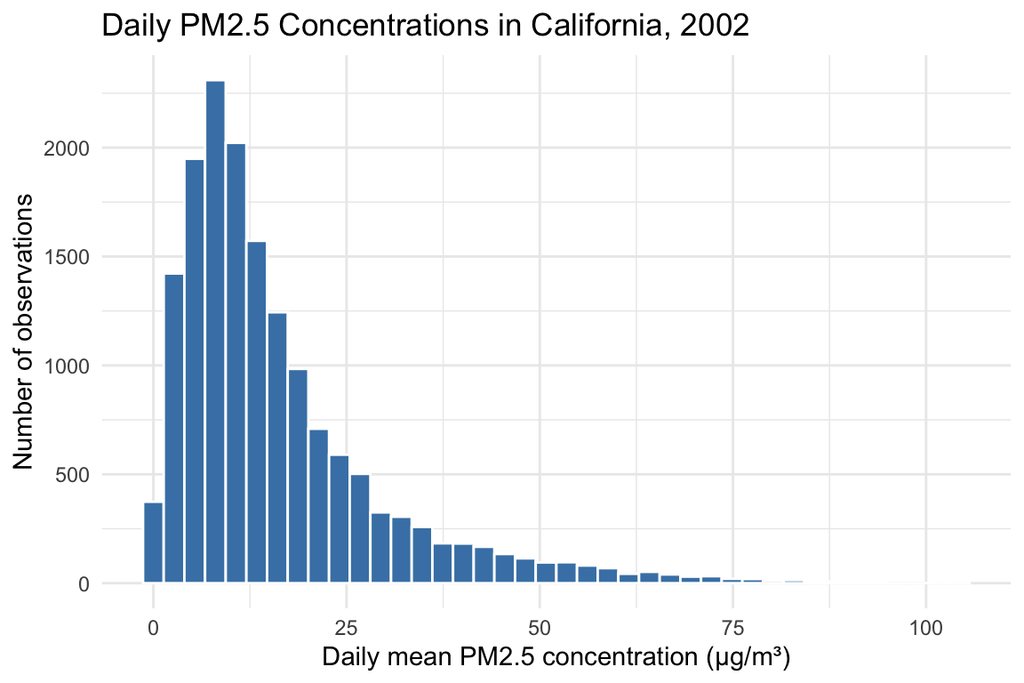

```r
ggplot(
  pm2002,
  aes(x = `Daily Mean PM2.5 Concentration`)
) +
  geom_histogram(
    bins = 40,
    fill = "steelblue",
    color = "white"
  ) +
  labs(
    title = "Daily PM2.5 Concentrations in California, 2002",
    x = "Daily mean PM2.5 concentration (µg/m³)",
    y = "Number of observations"
  ) +
  theme_minimal()
```

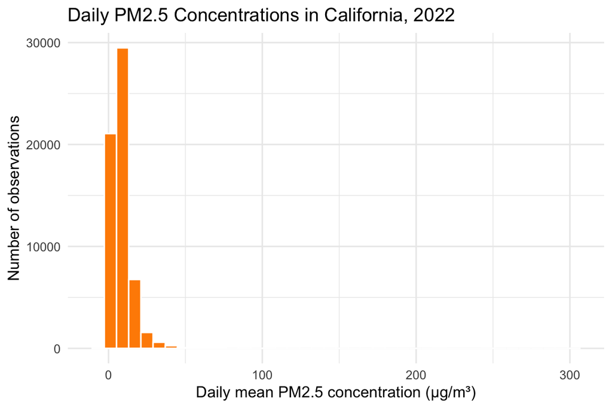

```r
ggplot(pm2022) +
  geom_histogram(
    mapping = aes(x = `Daily Mean PM2.5 Concentration`),
    bins = 40,
    fill = "darkorange",
    color = "white"
  ) +
  labs(
    title = "Daily PM2.5 Concentrations in California, 2022",
    x = "Daily mean PM2.5 concentration (µg/m³)",
    y = "Number of observations"
  ) +
  theme_minimal()
```

The 2002 dataset has 15,976 rows and 22 columns, while the 2022 dataset has 59,918 rows and the same 22 columns. I checked the first and last six rows of both datasets. They contain regular daily monitoring records, with dates from the beginning and end of each year. The two datasets also have the same variable names.

The variable types are similar in both years. `Date`, `Site ID`, `State`, and `County` are stored as character variables. PM2.5 concentration, AQI, latitude, and longitude are numeric. Since `Date` was originally stored as a character variable, it needed to be converted before I could extract the year.

Most observations were concentrated at lower PM2.5 concentrations, with a long tail extending toward higher values in 2002. In 2002, the mean concentration was 16.12 µg/m³ and the median was 12.0 µg/m³, compared with a mean of 8.41 µg/m³ and a median of 6.8 µg/m³ in 2022. The middle 50% of the observations ranged from 7.0 to 20.5 µg/m³ in 2002 and from 4.1 to 10.7 µg/m³ in 2022. No missing PM2.5 values appeared in the summary output. However, the minimum value in 2022 was −6.7 µg/m³, indicating that the dataset contained implausible negative concentrations that needed to be checked. The maximum value in 2022 was 302.5 µg/m³, which caused most observations appear concentrated on the left. Overall, the lower mean, median, and quartiles in 2022 provide early evidence that daily PM2.5 concentrations may have decreased, although monitoring locations and data-quality issues still need to be considered.

### 2. Combine the Two Years

```r
pm_combined <- rbind(pm2002, pm2022) |>
  rename(
    date = Date,
    pm25 = `Daily Mean PM2.5 Concentration`,
    site_id = `Site ID`,
    site_name = `Local Site Name`,
    county = County,
    latitude = `Site Latitude`,
    longitude = `Site Longitude`
  ) |>
  mutate(
    date = as.Date(date, format = "%m/%d/%Y"),
    year = as.integer(format(date, "%Y"))
  )
```

```r
dim(pm_combined)
```

```
[1] 75894    23
```

```r
names(pm_combined)
```

```
 [1] "date"                      "Source"
 [3] "site_id"                   "POC"
 [5] "pm25"                      "Units"
 [7] "Daily AQI Value"           "site_name"
 [9] "Daily Obs Count"           "Percent Complete"
[11] "AQS Parameter Code"        "AQS Parameter Description"
[13] "Method Code"               "Method Description"
[15] "CBSA Code"                 "CBSA Name"
[17] "State FIPS Code"           "State"
[19] "County FIPS Code"          "county"
[21] "latitude"                  "longitude"
[23] "year"
```

```r
glimpse(pm_combined)
```

```
Rows: 75,894
Columns: 23
$ date                        <date> 2002-01-05, 2002-01-06, 2002-01-08, 2002-…
$ Source                      <chr> "AQS", "AQS", "AQS", "AQS", "AQS", "AQS", …
$ site_id                     <chr> "060010007", "060010007", "060010007", "06…
$ POC                         <dbl> 1, 1, 1, 1, 1, 1, 1, 1, 1, 1, 1, 1, 1, 1, …
$ pm25                        <dbl> 25.1, 31.6, 21.4, 25.9, 34.5, 41.0, 29.3, …
$ Units                       <chr> "ug/m3 LC", "ug/m3 LC", "ug/m3 LC", "ug/m3…
$ `Daily AQI Value`           <dbl> 81, 93, 74, 82, 98, 115, 89, 62, 69, 107, …
$ site_name                   <chr> "Livermore", "Livermore", "Livermore", "Li…
$ `Daily Obs Count`           <dbl> 1, 1, 1, 1, 1, 1, 1, 1, 1, 1, 1, 1, 1, 1, …
$ `Percent Complete`          <dbl> 100, 100, 100, 100, 100, 100, 100, 100, 10…
$ `AQS Parameter Code`        <dbl> 88101, 88101, 88101, 88101, 88101, 88101, …
$ `AQS Parameter Description` <chr> "PM2.5 - Local Conditions", "PM2.5 - Local…
$ `Method Code`               <dbl> 120, 120, 120, 120, 120, 120, 120, 120, 12…
$ `Method Description`        <chr> "Andersen RAAS2.5-300 PM2.5 SEQ w/WINS", "…
$ `CBSA Code`                 <dbl> 41860, 41860, 41860, 41860, 41860, 41860, …
$ `CBSA Name`                 <chr> "San Francisco-Oakland-Hayward, CA", "San …
$ `State FIPS Code`           <chr> "06", "06", "06", "06", "06", "06", "06", …
$ State                       <chr> "California", "California", "California", …
$ `County FIPS Code`          <chr> "001", "001", "001", "001", "001", "001", …
$ county                      <chr> "Alameda", "Alameda", "Alameda", "Alameda"…
$ latitude                    <dbl> 37.68753, 37.68753, 37.68753, 37.68753, 37…
$ longitude                   <dbl> -121.7842, -121.7842, -121.7842, -121.7842…
$ year                        <int> 2002, 2002, 2002, 2002, 2002, 2002, 2002, …
```

```r
table(pm_combined$year)
```

```
 2002  2022
15976 59918
```

After combining the two datasets, the new data frame had 75,894 rows and 23 columns. I converted `Date` from character format to date format and used it to create the `year` column. The combined dataset contained 15,976 observations from 2002 and 59,918 from 2022, which matched the original datasets. I also shortened the names of the main variables so they would be easier to use in the remaining analysis.

### 3. Map of Monitoring Sites

```r
sites <- unique(
  pm_combined[, c("year", "site_id", "latitude", "longitude")]
)

table(sites$year)
```

```
2002 2022
 103  167
```

```r
site_counties <- unique(
  pm_combined[, c("year", "county")]
)

table(site_counties$year)
```

```
2002 2022
  48   50
```

```r
california_map <- map_data("state") %>%
  filter(region == "california")
```

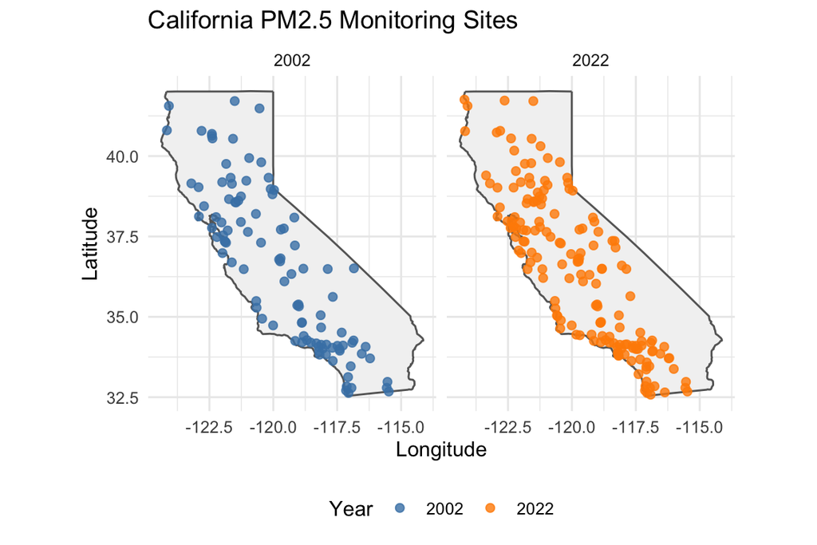

```r
ggplot() +
  geom_polygon(
    data = california_map,
    aes(x = long, y = lat, group = group),
    fill = "gray95",
    color = "gray40"
  ) +
  geom_point(
    data = sites,
    aes(
      x = longitude,
      y = latitude,
      color = factor(year)
    ),
    size = 1.8,
    alpha = 0.8
  ) +
  facet_wrap(~ year) +
  coord_quickmap() +
  scale_color_manual(
    values = c(
      "2002" = "steelblue",
      "2022" = "darkorange"
    )
  ) +
  labs(
    title = "California PM2.5 Monitoring Sites",
    x = "Longitude",
    y = "Latitude",
    color = "Year"
  ) +
  theme_minimal() +
  theme(legend.position = "bottom")
```

The monitoring sites were spread across California in both years, but they were not evenly distributed. The maps show several clusters of monitoring sites, while some parts of the state had fewer sites.

The site counts also show that the number of monitoring sites increased from 103 in 2002 to 167 in 2022, and the number of counties represented increased from 48 to 50. The 2022 map contains more points and appears denser than the 2002 map. Although the general pattern of clustered monitoring locations remained similar, the monitoring network included more sites and slightly more counties in 2022.

### 4. Check Missing and Implausible Values

```r
issue_summary <- pm_combined %>%
  group_by(year) %>%
  summarize(
    total_observations = n(),
    missing_n = sum(is.na(pm25)),
    missing_proportion = mean(is.na(pm25)),
    implausible_n = sum(pm25 < 0, na.rm = TRUE),
    implausible_proportion = mean(pm25 < 0, na.rm = TRUE)
  )
```

```r
issue_summary %>%
  mutate(
    missing_percent = missing_proportion * 100,
    implausible_percent = implausible_proportion * 100
  ) %>%
  select(
    year,
    total_observations,
    missing_n,
    missing_percent,
    implausible_n,
    implausible_percent
  )
```

```
# A tibble: 2 × 6
   year total_observations missing_n missing_percent implausible_n
  <int>              <int>     <int>           <dbl>         <int>
1  2002              15976         0               0             0
2  2022              59918         0               0           215
# ℹ 1 more variable: implausible_percent <dbl>
```

```r
monthly_issues <- pm_combined %>%
  filter(year == 2022) %>%
  mutate(
    month = format(date, "%m")
  ) %>%
  group_by(month) %>%
  summarize(
    total_observations = n(),
    implausible_n = sum(pm25 < 0, na.rm = TRUE),
    implausible_proportion = mean(pm25 < 0, na.rm = TRUE)
  ) %>%
  arrange(month)

monthly_issues
```

```
# A tibble: 12 × 4
   month total_observations implausible_n implausible_proportion
   <chr>              <int>         <int>                  <dbl>
 1 01                  5107            23               0.00450
 2 02                  4779            18               0.00377
 3 03                  5045             8               0.00159
 4 04                  4849             4               0.000825
 5 05                  5045            12               0.00238
 6 06                  4907            19               0.00387
 7 07                  4871            27               0.00554
 8 08                  5007             7               0.00140
 9 09                  4932            21               0.00426
10 10                  5146             4               0.000777
11 11                  5042            26               0.00516
12 12                  5188            46               0.00887
```

### Remove any missing and negative values

```r
pm_valid <- pm_combined %>%
  filter(!is.na(pm25), pm25 >= 0)

dim(pm_combined)
```

```
[1] 75894    23
```

```r
dim(pm_valid)
```

```
[1] 75679    23
```

```r
issue_summary %>%
  transmute(
    year,
    missing_percent =
      round(missing_proportion * 100, 2),
    implausible_percent =
      round(implausible_proportion * 100, 2)
  )
```

```
# A tibble: 2 × 3
   year missing_percent implausible_percent
  <int>           <dbl>               <dbl>
1  2002               0                0
2  2022               0                0.36
```

Neither dataset had missing PM2.5 values. There were no negative values in 2002, but 2022 had 215 negative values out of 59,918 observations, accounting for about 0.36% of that year’s observations. Because PM2.5 concentrations should not be negative, I treated these observations as implausible and removed them before the remaining analyses. The combined dataset decreased from 75,894 to 75,679 observations after the 215 negative observations were removed.

Negative values were found in every month of 2022. December had the highest number and proportion, with 46 negative observations, or about 0.89% of that month’s observations. July and November also had relatively high proportions, while April and October had the lowest. Although the negative values only occurred in 2022, there was no clear increasing or decreasing pattern across the months.

### 5. Three different levels of spatial resolution

### 5.1 State. Examine the primary question for the entire state.

```r
state_summary <- pm_valid %>%
  group_by(year) %>%
  summarize(
    observations = n(),
    sites = n_distinct(site_id),
    mean_pm25 = mean(pm25),
    median_pm25 = median(pm25),
    sd_pm25 = sd(pm25),
    q1 = quantile(pm25, 0.25),
    q3 = quantile(pm25, 0.75),
    maximum = max(pm25)
  )

state_summary
```

```
# A tibble: 2 × 9
   year observations sites mean_pm25 median_pm25 sd_pm25    q1    q3 maximum
  <int>        <int> <int>     <dbl>       <dbl>   <dbl> <dbl> <dbl>   <dbl>
1  2002        15976   103     16.1         12     13.9    7    20.5    104.
2  2022        59703   167      8.45         6.8    7.63   4.1  10.7    302.
```

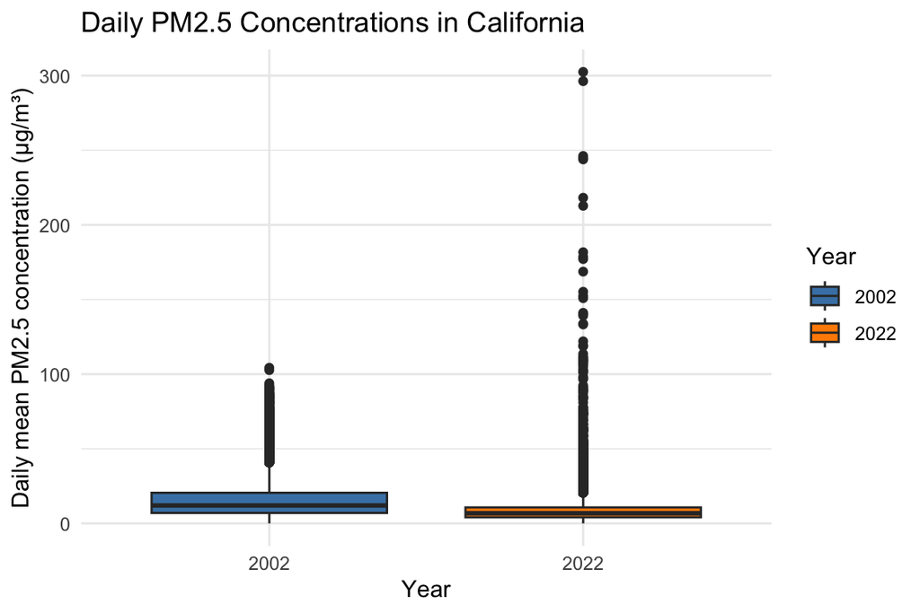

```r
pm_valid %>%
  ggplot() +
  geom_boxplot(
    mapping = aes(
      x = factor(year),
      y = pm25,
      fill = factor(year)
    )
  ) +
  scale_fill_manual(
    values = c(
      "2002" = "steelblue",
      "2022" = "darkorange"
    )
  ) +
  labs(
    title = "Daily PM2.5 Concentrations in California",
    x = "Year",
    y = "Daily mean PM2.5 concentration (µg/m³)",
    fill = "Year"
  ) +
  theme_minimal()
```

At the state level, both the mean and median PM2.5 concentrations were lower in 2022 than in 2002. The mean decreased from 16.12 to 8.45 µg/m³, and the median decreased from 12.0 to 6.8 µg/m³. The middle 50% of the observations also shifted downward, from 7.0–20.5 µg/m³ in 2002 to 4.1–10.7 µg/m³ in 2022.

The boxplot also shows a lower overall distribution in 2022. Although the maximum was higher in 2022, the median and quartiles were lower. At the state level, the daily PM2.5 observations were generally lower in 2022.

### 5.2 County. Examine the primary question for every county in California.

```r
county_summary <- pm_valid %>%
  group_by(county, year) %>%
  summarize(
    observations = n(),
    mean_pm25 = mean(pm25),
    median_pm25 = median(pm25),
    q1 = quantile(pm25, 0.25),
    q3 = quantile(pm25, 0.75)
  ) %>%
  arrange(county, year)

county_summary
```

```
# A tibble: 98 × 7
# Groups:   county [51]
   county        year observations mean_pm25 median_pm25    q1    q3
   <chr>        <int>        <int>     <dbl>       <dbl> <dbl> <dbl>
 1 Alameda       2002          201     14.3         10     6.7 16.9
 2 Alameda       2022         1790      8.21         7     4.7 10.5
 3 Butte         2002          473     14.8         11.5   7.3 17.8
 4 Butte         2022         1109      6.26         4.5   2.6  7.8
 5 Calaveras     2002           60      9.9          8     6   12.2
 6 Calaveras     2022          355      6.04         5     3.2  7.35
 7 Colusa        2002           95     11.7          9     5   14.5
 8 Colusa        2022          401      7.61         6.7   4.1 10.2
 9 Contra Costa  2002          276     15.1          9.5   6.5 16.6
10 Contra Costa  2022          815      8.24         7.2   4.8 10.4
# ℹ 88 more rows
```

```r
county_change <- county_summary %>%
  group_by(county) %>%
  filter(n() == 2) %>%
  summarize(
    median_2002 = median_pm25[year == 2002],
    median_2022 = median_pm25[year == 2022],
    change = median_2022 - median_2002
  ) %>%
  arrange(change)

county_change
```

```
# A tibble: 47 × 4
   county      median_2002 median_2022 change
   <chr>             <dbl>       <dbl>  <dbl>
 1 Tulare             20           8.7  -11.3
 2 Riverside          17.9         8.2   -9.7
 3 Kern               16.5         7     -9.5
 4 Merced             16.6         7.5   -9.1
 5 Kings              18          10.6   -7.4
 6 Los Angeles        17.4        10.3   -7.1
 7 Butte              11.5         4.5   -7
 8 San Joaquin        12           5.4   -6.6
 9 Ventura            13.1         6.5   -6.6
10 Orange             15.1         8.6   -6.5
# ℹ 37 more rows
```

```r
county_change %>%
  summarize(
    counties_compared = n(),
    counties_decreased = sum(change < 0),
    counties_increased = sum(change > 0),
    counties_unchanged = sum(change == 0)
  )
```

```
# A tibble: 1 × 4
  counties_compared counties_decreased counties_increased counties_unchanged
              <int>              <int>              <int>              <int>
1                47                 41                  5                  1
```

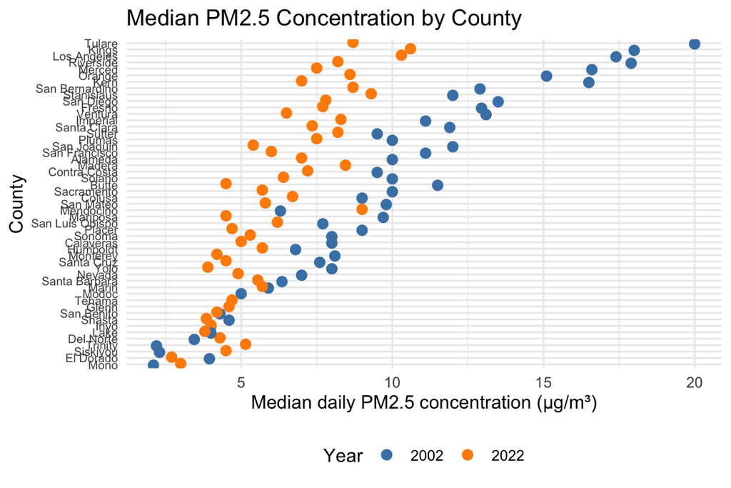

```r
ggplot(
  county_summary,
  aes(
    x = median_pm25,
    y = reorder(county, median_pm25),
    color = factor(year),
    group = factor(year)
  )
) +
  geom_point(
    size = 2.5,
    position = position_dodge(width = 0.5)
  ) +
  scale_color_manual(
    values = c(
      "2002" = "steelblue",
      "2022" = "darkorange"
    )
  ) +
  labs(
    title = "Median PM2.5 Concentration by County",
    x = "Median daily PM2.5 concentration (µg/m³)",
    y = "County",
    color = "Year"
  ) +
  theme_minimal() +
  theme(
    axis.text.y = element_text(size = 7),
    legend.position = "bottom"
  )
```

Of the 47 counties with data in both years, 41 had a lower median PM2.5 concentration in 2022, five had a higher median, and one had no change. Some of the largest decreases occurred in Tulare, Riverside, Kern, Merced, Kings, and Los Angeles counties. For example, the median in Los Angeles County decreased from 17.4 µg/m³ in 2002 to 10.3 µg/m³ in 2022. A few counties, including Trinity, Mendocino, and Siskiyou, had higher medians in 2022. Overall, most counties followed the statewide decrease, although the change was not the same in every county.

### 5.3 City. Los Angeles county examine every site.

```r
la_data <- pm_valid %>%
  filter(county == "Los Angeles")
```

```r
la_site_summary <- la_data %>%
  group_by(site_id, site_name, year) %>%
  summarize(
    observations = n(),
    mean_pm25 = mean(pm25),
    median_pm25 = median(pm25),
    q1_pm25 = quantile(pm25, 0.25),
    q3_pm25 = quantile(pm25, 0.75)
  ) %>%
  arrange(site_id, year)

la_site_summary
```

```
# A tibble: 25 × 8
# Groups:   site_id, site_name [18]
   site_id   site_name   year observations mean_pm25 median_pm25 q1_pm25 q3_pm25
   <chr>     <chr>      <int>        <int>     <dbl>       <dbl>   <dbl>   <dbl>
 1 060370002 Azusa       2002          339     20.8        18.7    11.3     27.0
 2 060370002 Azusa       2022           76      9.72        9.65    5.38    13.0
 3 060370016 Glendora    2022          362      8.50        7.9     4.4     11.9
 4 060371002 Burbank     2002          122     24.0        21.6    14.9     28.8
 5 060371103 Los Angel…  2002          365     22.0        19.3    13.9     26.9
 6 060371103 Los Angel…  2022          906     11.6        10.9     8.33    14.3
 7 060371201 Reseda      2002          120     18.9        17.0    11.4     22.5
 8 060371201 Reseda      2022          482     10.7        10.3     7.5     13.4
 9 060371301 Lynwood     2002          122     23.3        19.8    15.2     28.2
10 060371302 Compton     2022          723     13.0        11.9     9.2     15.1
# ℹ 15 more rows
```

```r
la_sites <- unique(
  la_data[, c("year", "site_id")]
)

table(la_sites$year)
```

```
2002 2022
  10   15
```

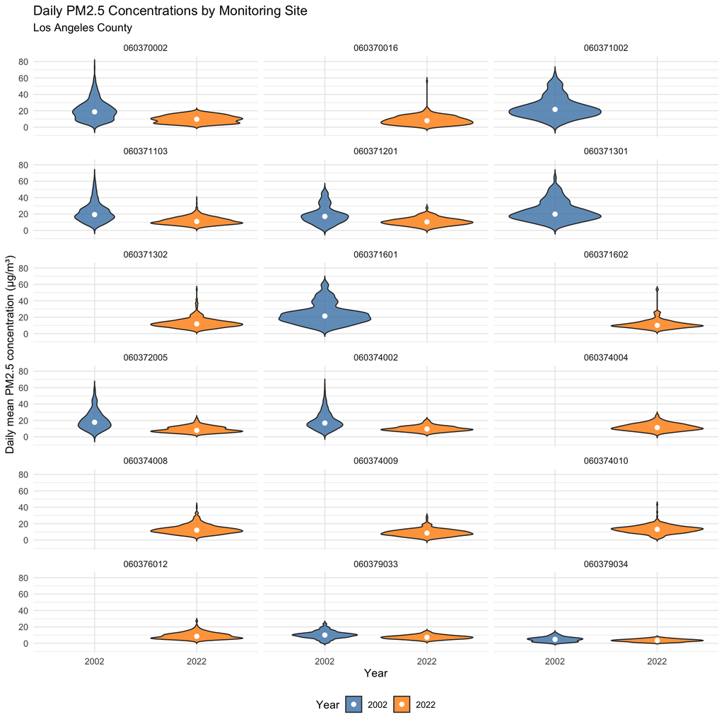

Distribution of daily PM2.5 concentrations by monitoring site in Los Angeles County.

```r
ggplot(
  la_data,
  aes(
    x = factor(year),
    y = pm25,
    fill = factor(year)
  )
) +
  geom_violin(
    trim = FALSE,
    alpha = 0.8
  ) +
  stat_summary(
    fun = median,
    geom = "point",
    color = "white",
    size = 1.8
  ) +
  facet_wrap(
    ~ site_id,
    ncol = 3
  ) +
  scale_fill_manual(
    values = c(
      "2002" = "steelblue",
      "2022" = "darkorange"
    )
  ) +
  labs(
    title = "Daily PM2.5 Concentrations by Monitoring Site",
    subtitle = "Los Angeles County",
    x = "Year",
    y = "Daily mean PM2.5 concentration (µg/m³)",
    fill = "Year"
  ) +
  theme_minimal() +
  theme(
    legend.position = "bottom"
  )
```

```r
la_comparable_sites <- la_site_summary %>%
  group_by(site_id) %>%
  filter(n() == 2) %>%
  ungroup()

unique(la_comparable_sites$site_id)
```

```
[1] "060370002" "060371103" "060371201" "060372005" "060374002" "060379033"
[7] "060379034"
```

```r
la_site_change <- la_comparable_sites %>%
  group_by(site_id) %>%
  summarize(
    median_2002 = median_pm25[year == 2002],
    median_2022 = median_pm25[year == 2022],
    change = median_2022 - median_2002
  ) %>%
  arrange(change)

la_site_change
```

```
# A tibble: 7 × 4
  site_id   median_2002 median_2022 change
  <chr>           <dbl>       <dbl>  <dbl>
1 060372005        17.8        7.9   -9.9
2 060370002        18.7        9.65  -9.05
3 060371103        19.3       10.9   -8.4
4 060374002        16.8        9.6   -7.25
5 060371201        17.0       10.3   -6.75
6 060379033        10          7.3   -2.7
7 060379034         4.8        3.4   -1.4
```

I used violin plots to compare the distribution of daily PM2.5 concentrations at each monitoring site. Wider parts of a violin indicate ranges containing more observations, and the white point marks the median.

Los Angeles County had 10 monitoring sites in 2002 and 15 in 2022, but only seven sites had observations in both years. All seven comparable sites had lower median PM2.5 concentrations in 2022, although the amount of decrease differed across sites. The other sites could not be directly compared because they were monitored in only one of the two years. Overall, the comparable sites showed lower PM2.5 concentrations in 2022, but the change in monitoring sites should be considered when comparing the two years.